# A Survival Model in Stan_with comments by Tiago

Eren Metin Elçi

2018-09-03

The goal of this short case study is to demonstrate the essentials of a Bayesian workflow using the probabilistic programming language Stan. The dataset we consider here is known as the mastectomy dataset. As the title already suggest, we will implement the simplest, and probably most commonly used survival model, also sometimes known as (Cox’s) proportional hazard model.

This case study is motivated by Austin Rochford’s related PyMC3 [blog post](https://austinrochford.com/posts/2015-10-05-bayes-survival.html). See also [this](https://docs.pymc.io/notebooks/bayes_param_survival_pymc3.html) updated version, now part of the official PyMC3 documentation. The same dataset was also studied by the same author in [this](https://docs.pymc.io/notebooks/survival_analysis.html) related case study.

The beauty or advantage of the Bayesian framework is that we can avoid any technicality or approximation due to what is known as *ties* in the dataset, usually encountered in real datasets and which need special treatments/considerations in frequentist frameworks (see e.g. `coxph`). This is because we model the baseline hazard explicitly and hence do not need to revert to what is known as a pseudo-likelihood.

For a good and concise description of the frequentist approach and the utilized pseudo-likelihood, see chapter 9.4 and the related appendix in [Computer Age Statistical Inference](https://web.stanford.edu/~hastie/CASI/index.html) by Efron and Hastie.

Now, let’s first have a look at the data:

A mastectomy dataset

| time | event | metastized |
| --- | --- | --- |
| 23 | TRUE | 0 |
| 47 | TRUE | 0 |
| 69 | TRUE | 0 |
| 70 | FALSE | 0 |
| 100 | FALSE | 0 |
| 101 | FALSE | 0 |
| 148 | TRUE | 0 |
| 181 | TRUE | 0 |
| 198 | FALSE | 0 |
| 208 | FALSE | 0 |

More precisely, each row in the dataset represents observations from a woman diagnosed with breast cancer that underwent a mastectomy.

- The column `time` represents the time (in months) post-surgery that the woman was observed.
- The column `event` indicates whether or not the woman died during the observation period.
- The column `metastized` represents whether the cancer had metastized prior to surgery.

  The cancers are classified as having metastized or not based on a histochemical marker.

**TC:** On this part I would add some descriptive stats on each variable you might find important to mention (e.g. number of patents, survival times for women with and without treatment, etc). This, for instance, might be helpful for the reader to understand how you have choosen the prior distribution for $\gamma$ and give a big picture of the problem you are trying to solve by using this type of models.

# Some math (some notation)

Central to survival models is the survival function $S(t)$ defined as

$$S(t) = \mathbb{P}[T>t] = e^{-H(t)}$$
Here $T$ is a the survival time of an individual and thus $T>t$ denotes the event that the patient or individual survived beyond time $t$. $H(t)$ is known as the cumulative hazard and can be shown to be given by

$$H(t) = \int_{0}^{t}{\rm d}u~\lambda(u)$$

Here we introduced the hazard rate $\lambda(t)$

We discard the dependence on latent parameters such as $\mathbf{\beta}$ or $\gamma$ below, for the sake of readability.

$$h(t;\mathbf{x}) = h_0(t) e^{\mathbf{x}'\cdot\boldsymbol{\beta}}$$

Here $\mathbf{x}$ is a vector of covariates describing an individual. The above makes it apparent why such models are often referred to as *proportional* hazard models. Further, we make the assumption that the baseline hazard $h_0$ fulfills

In our mastectomy dataset it is simply a scalar indicator corresponding to the column `metastized` above.

$$h_0(t) = h_0.$$

Our Bayesian analysis therefore has the unknown parameters $\boldsymbol{\beta}$ and $h_0$ where we parametrize the latter as $h_0 = e^\gamma$. Note that the above implies (or is equivalent to) $T$ having an exponential law with rate parameter equal to $\exp{(\mathbf{x}'\cdot \boldsymbol{\beta}+ \gamma)}$.

For the keen reader, try to verify (or convince yourself) that one has in the limit $dt\rightarrow 0$

$$h(t)dt \doteq \mathbb{P}\left[T\in (t,t+dt) \vert T\geq t\right]$$

**TC:** At the end of this section I would try to shortly describe the model you are going to fit bellow by stating, for example, which predictors you are including in x’(maybe include mock notation for the cumulative hazard function like $h(t;\mathbf{methastised}) = h_0(t) e^{\mathbf{methastised}\cdot\boldsymbol{\beta}}$), and maybe finish by shortly describing what the model will tell you about the survival rate for each individual’s survival time given what you include in the model.

# Stan

Now let’s get our hands dirty (or actually our keyboard) and start specifying our corresponding generative model in Stan!

## Data block

Here we define precisely the type and dimensions of data provided externally to Stan.

E.g. via rstan, pystan or cmdstan.

```
data {
    int<lower=0> N_uncensored;
    int<lower=0> N_censored;
    int<lower=1> NC;
    matrix[N_censored,NC] X_censored;
    matrix[N_uncensored,NC] X_uncensored;
    vector<lower=0>[N_censored] times_censored;
    vector<lower=0>[N_uncensored] times_uncensored;
}
```

**TC:** I would add comments on the Stan code simply describing what is containded in each data argument and maybe just add something on the text about what does censored and uncensroed means. Then I would just add a line saying this is going to important for computational reasons, which you will later clarify.

## Parameters block

Here we define all parameters that we wish to infer.

```
parameters {
    vector[NC] betas;
    real intercept;
}
```

Note that `betas` corresponds to $\boldsymbol{\beta}$ and `intercept` to $\gamma$.

## Model block

Here we define the likelihood and priors. Before we do so, I’d like to quote [Jonah Gabry](http://iserp.columbia.edu/people/jonah-gabry):

> “Choosing priors is about including information while allowing the chance of being wrong.”

In this sense, let’s hack the model block:

```
model {
    betas ~ normal(0,2);
    intercept ~ normal(-5,2);
    target += exponential_lpdf(times_uncensored | exp(intercept+X_uncensored*betas));
    target += exponential_lccdf(times_censored | exp(intercept+X_censored*betas));
}
```

Note that implicit here is the assumption that survival times are mutually independent.

Moreover, above we use *vectorized* statements, which makes the computation more efficient than using, say, a for loop and iterating over all individuals. This is the main reason why we decided to work with the `_censored` and `_uncensored` suffixes and split the data, as opposed to the variant where one keeps the data together and provides an boolean array/vector specifying which patients have a (right-) censored survival time.

## Model compilation

```r
library(rstan)
rstan_options(auto_write = TRUE)
sm <- stan_model("./exponential_survival_simple_ppc.stan")
```

# Data preparation

```r
N <- nrow(df)
X <- as.matrix(pull(df, metastized))
is_censored <- pull(df,event)==0
times <- pull(df,time)
msk_censored <- is_censored == 1
N_censored <- sum(msk_censored)
```

Combine (couple) all the data into one named list with reference names corresponding precisely to the actual names as defined in the data block of our Stan model.

```r
stan_data <- list(N_uncensored=N-N_censored,
                  N_censored=N_censored,
                  X_censored=as.matrix(X[msk_censored,]),
                  X_uncensored=as.matrix(X[!msk_censored,]),
                  times_censored=times[msk_censored],
                  times_uncensored = times[!msk_censored],
                  NC=ncol(X)
)
```

# Fitting the model

```r
fit <- sampling(sm, data=stan_data, seed=42, chains=4, cores=2, iter=4000)
```

# Inspecting results

Consider especially the `ess` and `rhat` columns below, which correspond to the effective sample size and the potential scale reduction statistics. In a nutshell, `rhat` should be very close to $1$ which indicates that the chain(s) mixed (converges) and `ess` should be as close as possible to the total number of MCMC iterations (excluding burn-in).

Starting in Stan 2.18 `ess` can in fact be larger than the number of MCMC iterations, essentially due to what is known as anti-correlations (yes NUTS and HMC can sometimes be unbelievable super-efficient!). For more details on the two quantities see the section [General MCMC diagnostics](http://mc-stan.org/bayesplot/articles/visual-mcmc-diagnostics.html#general-mcmc-diagnostics) in the bayesplot vignette [Visual MCMC diagnostics using the bayesplot package](http://mc-stan.org/bayesplot/articles/visual-mcmc-diagnostics.html). For a detailed example regarding the updates on `ess` and `rhat` in 2.18 I can highly recommend Aki Vehtari’s [Rank-normalized split-Rhat and relative efficiency estimates](https://avehtari.github.io/rhat_neff/rhat_neff.html)

**TC:**

- line 180: “chain(s) mixed (converged)”?
- line 181: “excluding warmup”?

Posterior summary

| term | estimate | std.error | conf.low | conf.high | rhat | ess |
| --- | --- | --- | --- | --- | --- | --- |
| intercept | -5.7456285 | 0.4259313 | -6.6556501 | -4.992377 | 1.001476 | 1669 |
| betas[1] | 0.8702448 | 0.4787253 | -0.0027207 | 1.858607 | 1.001180 | 1761 |

```
## 0 of 8000 iterations ended with a divergence.
```

```
## 0 of 8000 iterations saturated the maximum tree depth of 10.
```

## Visual inspection of the posterior

```r
library(bayesplot)
library(survival)
post <- as.array(fit)
fit_cox <- coxph( Surv(time, event)~metastized, data=df)
coef_cox <- coef(fit_cox)
se_cox <- sqrt(fit_cox$var)
```

**TC:** OCD comment ;p

- line 209: extra space after `coxph(`.

### Kernel density plots of posterior draws with chains separated but overlaid on a single plot.

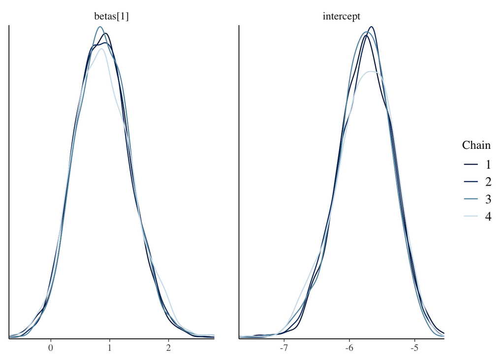

```r
mcmc_dens_overlay(post, pars=c("betas[1]", "intercept"))
```

### Plots of uncertainty intervals computed from posterior draws with all chains merged.

The three vertical lines below (from left to right) correspond to the frequentist’s point estimate minus the standard error, the point estimate and the point estimate plus the standard error of the regression coefficient, respectively.

Using the `coxph` routine in the survival package, see the code of this RMarkdown.

**TC:** Two comments of this plot:

- I would make just state what the dot and uncertainty interval you are using for the posterior;
- You say you include 3 vertical lines on the plot, but the plot displays 4 (one at 0 as well). I would either say the “(…) three black vertical lines (…)” or change their appearance so they can’t be cofused with the line at 0:

#### TC suggestion:

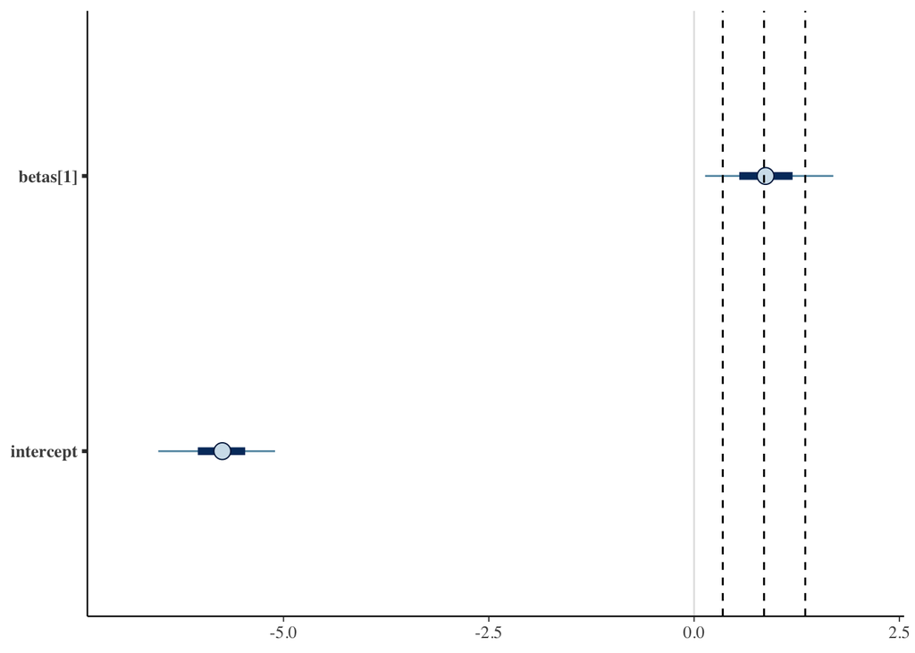

```r
mcmc_intervals(post, pars=c("betas[1]", "intercept")) +
  vline_at(c(coef_cox-se_cox, coef_cox, coef_cox+se_cox),
           linetype="dashed") # TC
```

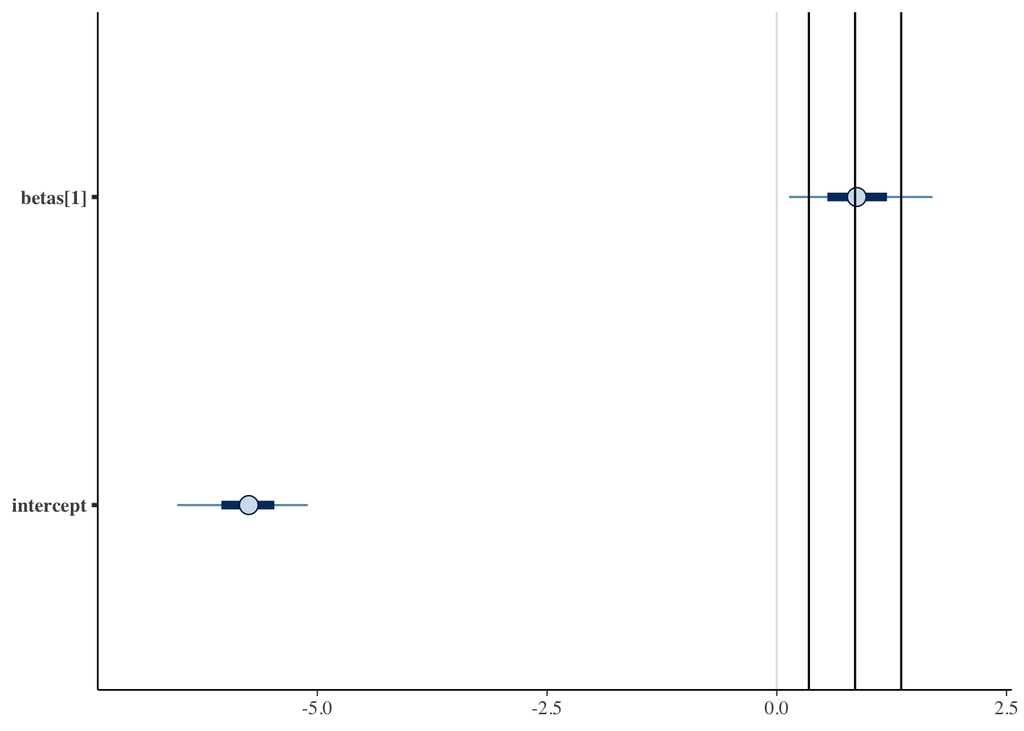

```r
mcmc_intervals(post, pars=c("betas[1]", "intercept")) +
  vline_at(c(coef_cox-se_cox, coef_cox, coef_cox+se_cox))
```

### Pairs plot

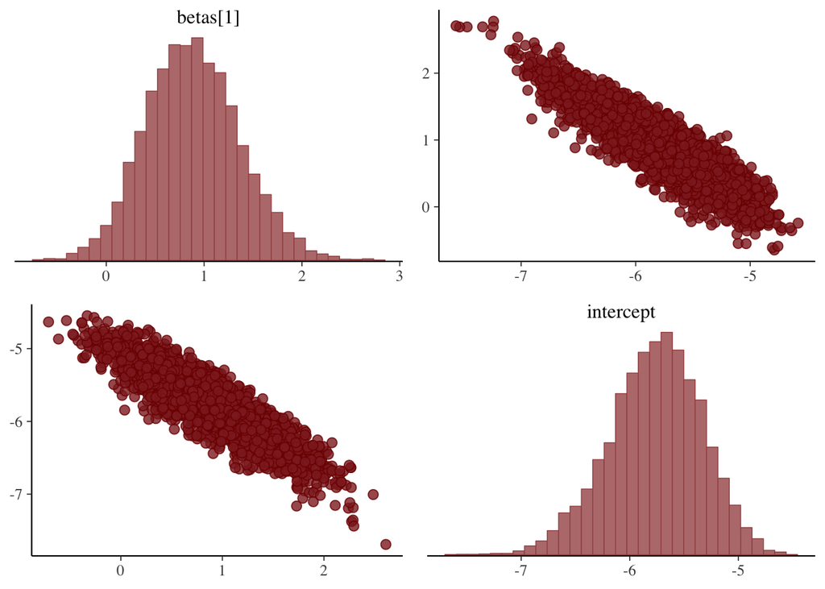

```r
color_scheme_set("red")
mcmc_pairs(post, pars=c("betas[1]", "intercept"))
```

### Hex plot

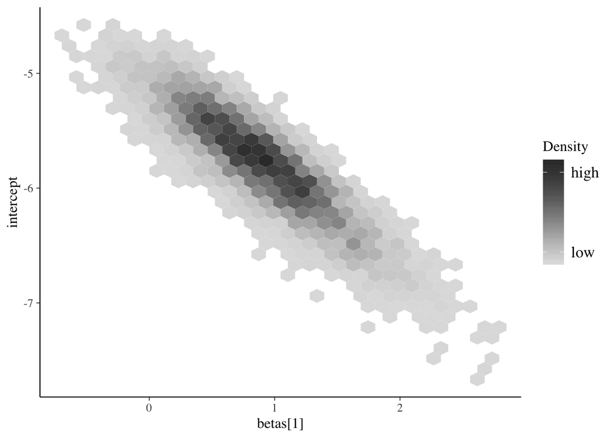

```r
color_scheme_set("gray")
mcmc_hex(post, pars=c("betas[1]", "intercept"))
```